# HW2-exploration

Author

Amanda Overbye

Published

February 7, 2025

## Load necessary packages and read in your data.

```r
# Load packages
library(tidycensus)
library(tidyverse)
library(ggplot2)
library(tmap)
library(here)
library(janitor)
library(usdata)
library(tigris)
library(sf)
library(scales)
library(airportr)
library(ggmap)
library(maps)
```

```r
# Testing maps
map_data_es <- map_data('world')[map_data('world')$region == "USA",]
world <- worldMapEnv
```

```r
# Load in the data
freight_df <- read.csv(here("data", "International_Report_Freight_20250205.csv"))

air_coords <- airports
```

# Cleaning & Wrangling

**Data seems pretty clean already**

```r
# Clean names
clean_freight <- freight_df %>%
clean_names()
clean_airports <- air_coords %>%
  clean_names()
```

```r
# Remove type column
clean_freight <- clean_freight %>%
  select(-type)
```

```r
# Remove all the columns I don't need
clean_airports <- clean_airports %>%
  select(-timezone, -type, -altitude, -country_code, -country_code_alpha_2, -country_code_alpha_3, -open_flights_id, -source)
```

```r
# Rename column for join
clean_freight <- clean_freight %>%
  rename(iata = usg_apt)
```

```r
# Create 2024 df to be able to test basic geographical ideas without a giant df
freight_2024 <- clean_freight %>%
  filter(year == 2024) %>%
  filter(carriergroup == 1)
```

### Join the clean_airports and freight_2024

```r
# Join the data sets
geo_planes2024 <- full_join(freight_2024, clean_airports)
```

```r
# Filter to just the US
geo_planes2024 <- geo_planes2024 %>%
  filter(country == "United States")
```

# Three Exploratory Plots

## The Basic Bar Graph

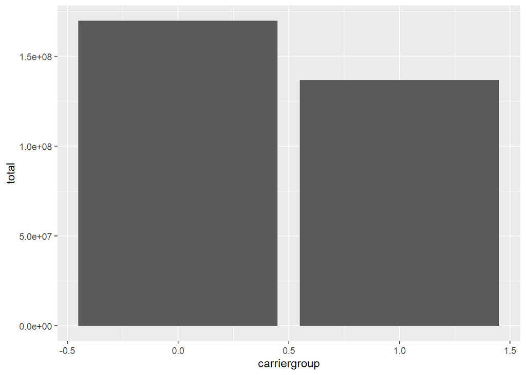

```r
# Create basic bar plot based on carrier group
ggplot(clean_freight, aes(x = carriergroup, y = total)) +
  geom_col() +
  scale_x_continuous(labels = scales::comma)
```

```r
# Summarize total flights per airport
airport_flights <- geo_planes2024 %>%
  group_by(iata, name, latitude, longitude) %>%
  summarise(total_flights = sum(total, na.rm = TRUE)) %>%
  arrange(desc(total_flights))

# Get the airport with the highest flights
top_airport <- airport_flights %>% slice(1)
print(top_airport)
```

```
# A tibble: 1,512 × 5
# Groups:   iata, name, latitude [1,512]
   iata  name                                latitude longitude total_flights
   <chr> <chr>                                  <dbl>     <dbl>         <int>
 1 AAF   Apalachicola Regional Airport           29.7     -85.0             0
 2 AAP   Andrau Airpark                          29.7     -95.6             0
 3 ABE   Lehigh Valley International Airport     40.7     -75.4             0
 4 ABI   Abilene Regional Airport                32.4     -99.7             0
 5 ABL   Ambler Airport                          67.1    -158.              0
 6 ABQ   Albuquerque International Sunport       35.0    -107.              0
 7 ABR   Aberdeen Regional Airport               45.4     -98.4             0
 8 ABY   Southwest Georgia Regional Airport      31.5     -84.2             0
 9 ACK   Nantucket Memorial Airport              41.3     -70.1             0
10 ACT   Waco Regional Airport                   31.6     -97.2             0
# ℹ 1,502 more rows
```

```r
# Load US states data
usa_map <- map_data("state")
```

## The Maps of Airports

### Map 1

```r
# Ensure latitude and longitude are numeric
geo_planes2024$latitude <- as.numeric(geo_planes2024$latitude)
geo_planes2024$longitude <- as.numeric(geo_planes2024$longitude)

# Create the basemap with airport locations
ug <- ggplot() +
  # Plot the USA basemap
  geom_polygon(data = usa_map, aes(x = long, y = lat, group = group),
               fill = "lightgray", color = "black") +
  # Add airport locations as points
  geom_point(data = geo_planes2024,
             aes(x = longitude, y = latitude, color = carrier),
             size = 3, alpha = 0.7) +
  # Add labels for airport IATA codes
  theme(legend.position = "none") +
  labs(title = "Airport Locations in the Contiguous USA",
       x = "Longitude", y = "Latitude", color = "Carrier")
```

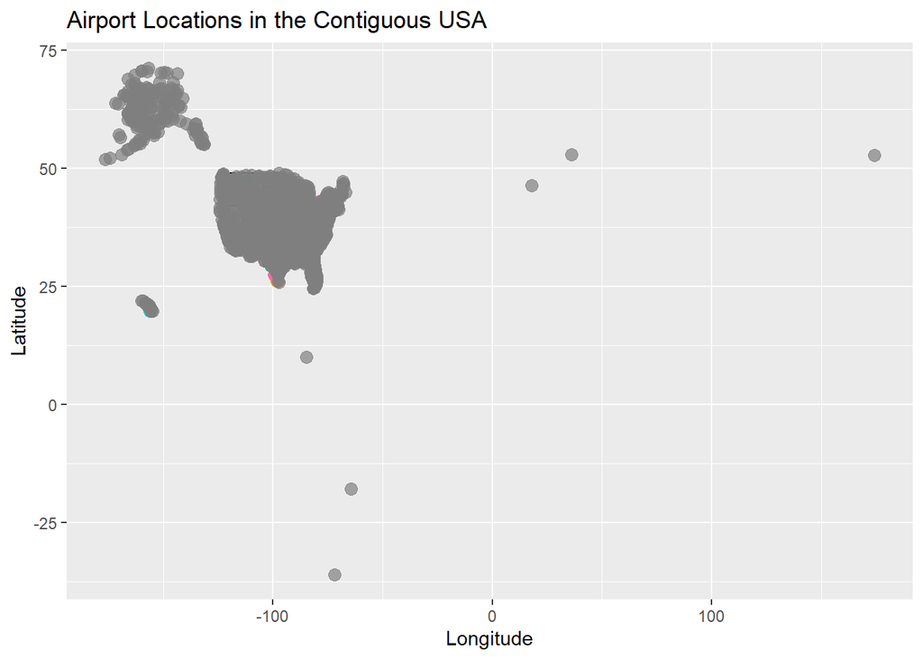

```r
ug
```

### Map 2

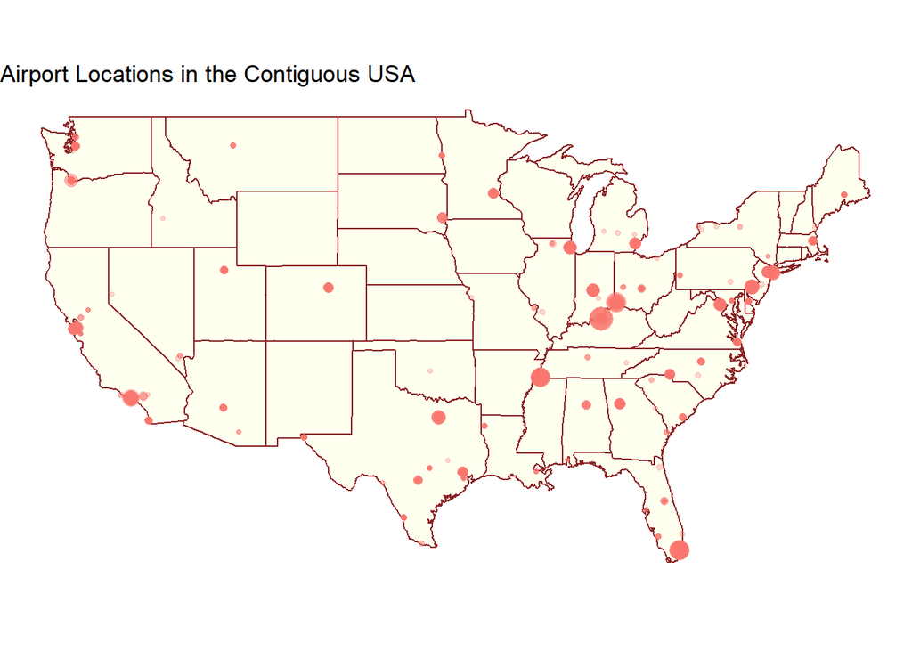

```r
# Filter geo_planes2024 to include only airports in the contiguous USA
geo_planes2024 <- geo_planes2024 %>%
  filter(latitude >= 24, latitude <= 50,  # Contiguous U.S. latitude range
         longitude >= -125, longitude <= -66)  # Contiguous U.S. longitude range

# Plot the map with airport locations
ggplot() +
  # Plot the USA basemap
  geom_polygon(data = usa_map, aes(x = long, y = lat, group = group),
               fill = "ivory", color = "brown4") +
  # Add airport locations as points
  geom_point(data = geo_planes2024,
             aes(x = longitude, y = latitude, color = "blue4", size = total),
  alpha = 0.3) +
  coord_fixed(1.3) +  # Fix aspect ratio
  theme_void() +
  theme(legend.position = "none") +
  labs(title = "Airport Locations in the Contiguous USA",
       x = "Longitude", y = "Latitude", color = "Carrier")
```

## Data filtering and grouping for graph 3

```r
# Create df with avg for total for each year and split carriergroup
time_data <- clean_freight %>%
  group_by(year, carriergroup) %>%   # Group by year
  summarise(mean_flights = mean(total, na.rm = TRUE),.groups = "drop") %>%
  pivot_wider(names_from = carriergroup, values_from = mean_flights) %>%
  rename(domestic = '1', foreign = '0')
```

## The Timeline Graph

**Random notes that I will forget if I delete, please ignore** Carrier Group Code - 1 denotes US domestic air carriers, 0 denotes foreign air carriers A “foreign air carrier” is defined by 49 U.S.C. 40102(21) as “a person, not a citizen of the United States, undertaking by any means, directly or indirectly, to provide foreign air transportation.” so the “foreign flights” are flights by companies not owned in the usa

Total Metric flown by scheduled service and charter operations

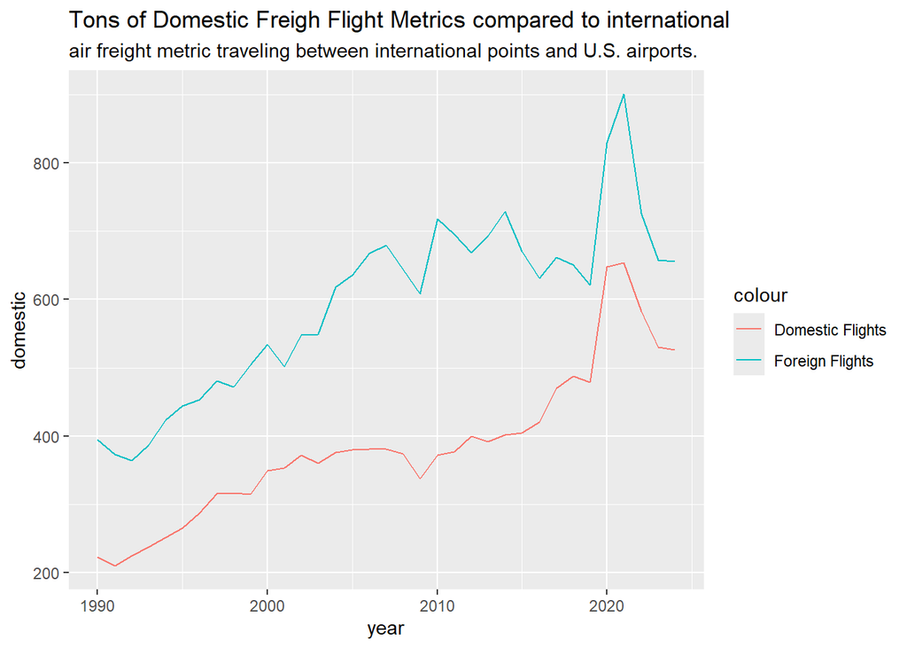

```r
ggplot(time_data, aes(year)) +
  geom_line(aes(y = domestic, colour = "Domestic Flights")) +
  geom_line(aes(y = foreign, colour = "Foreign Flights")) +
  labs(title = "Tons of Domestic Freigh Flight Metrics compared to international",
    subtitle = "air freight metric traveling between international points and U.S. airports.")
```

# Answering Questions

2c. Answer questions After completing the above steps, answer the following questions:

1. What have you learned about your data? Have any potentially interesting patterns emerged?

2. In HW #1, you outlined some questions that you wanted to answer using these data. Have you made any strides towards answering those questions? If yes, how so? If no, what next steps do you need to take (e.g. I need to create X plot type, I still need to track down Y data, I need to restructure existing data so that you can visualize it in Z ways, etc.)?

I think these graphs brought up good questions regarding whos going where and why. I will need to put more time into the map feature. I think the dips and peaks in the timeline will be very interesting to explore, especially seeing if they impacted charter flights as much as planned flights. I would expect to see a bump in charters are the pandemic, perhaps.

3. What challenges do you foresee encountering with your data? These can be data wrangling and / or visualization challenges.

I am realizing there may be some trouble defining “flight metrics.” What I have found so far is that it seems to be a fancy equation that includes fuel, open space on the plane, and how much freight was being carried. There are also a lot of airports in the world, so organizing those will be a challenge.